# Stimulus selection for schemaVR3

Jörn Alexander Quent

November 06, 2018

# Introduction

As stated [here](https://jaquent.me/2018/08/01/282/), I am planning a final experiment in the series of schemaVR, [schemaVR3](https://jaquent.me/category/schemavr3/). The reason for running another experiment is to make sure that the U-shape relationship does not depend on a specific combination of objects and locations and furthermore to see whether recollection and familiarity might indeed be helpful to differentiate that U-shape. Because the 3AFC task did not yield additional evidence beyond what 3D location recall task provides, we decided to drop the 3AFC task. This will reduce limitations in selecting appropriate sets because there is no need to take the expectedness of foils into account. For schemaVR3, I will select five sets that will be used in the experiment (for rationale look [here](https://jaquent.me/2018/08/01/282/)).

# Libraries

```r
library(ggplot2)
library(tidyr)
library(knitr)
library(gridExtra)
library(grid)
```

# The algorithm

```r
###############################################################
# Functions
convertSeconds <- function(seconds){
  seconds <- round(seconds)
  if(seconds < 60){
    # Less than a minute
    time    <- paste(round(seconds), 'sec')
  }
  if(seconds >= 60 & seconds < 3600){
    # Less than an hour
    minutes <- (seconds - seconds %% 60)/60
    seconds <- seconds %% 60
    time    <- paste(minutes, 'min,', round(seconds), 'sec')
  }
  if(seconds >= 3600 & seconds < 86400){
    # Less than a day
    hours   <-  (seconds - seconds %% 3600)/3600
    minutes <-  ((seconds %% 3600) - (seconds %% 3600) %% 60)/60
    seconds <-  (seconds %% 3600) %% 60
    time    <- paste(hours, 'h,', minutes, 'min,', round(seconds), 'sec')
  }
  if(seconds >= 86400){
    # More than a day
    days    <- (seconds - seconds %% 86400)/86400
    hours   <- ((seconds %% 86400) - (seconds %% 86400) %% 3600)/3600
    minutes <- (((seconds %% 86400) %% 3600) - ((seconds %% 86400) %% 3600) %% 60)/60
    seconds <- ((seconds %% 86400) %% 3600) %% 60
    time    <- paste(days, 'd, ', hours, 'h,', minutes, 'min,', round(seconds), 'sec')
  }
  return(time)
}

progressDisplay <- function(i, iterations, startTime){
  startTime     <- as.numeric(startTime)
  currentTime   <- as.numeric(Sys.time())
  elapsedTime   <- currentTime - startTime
  predictedTime <- elapsedTime * (1/(i/iterations))
  cat('\rProgress: |',rep('=',floor((i/iterations)*50)),rep(' ',50 - floor((i/iterations)*50)),'|',
      '\tElapsed time:', convertSeconds(elapsedTime),
      '\tTotal time:',    convertSeconds(predictedTime), '\t\t',
      sep = '')
}

###############################################################
# Loading data
# Preparing
subNo                <- 1:6
N                    <- length(subNo)
numberObjects        <- 20
kitchenOjects        <- 1:12
numberKitchenObjects <- length(kitchenOjects)
nonKitchenObjets     <- 13:30
locationRatings      <- array(data = NA, dim = c(numberObjects, numberObjects, N))

# Sequently loading data
for(i in 1:N){
  locationRatings[,,i] <- matrix(scan(paste('/home/aq01/Projects/schemaVR/schemaVR3/preparation/schemaVR2_stimulusSelection/data/locationRatings_', as.character(subNo[i]) ,'.dat', sep = '')), byrow = TRUE, ncol = 20)
}

# Calculating ranks
rankedRatings <- array(data = NA, dim = c(numberObjects, numberObjects, N))

for(i in 1:N){
  rankedRatings[,,i] <- rank(locationRatings[,,i])
}

# Calculating mean rank per object/ location
meanRankedRatings <- apply(rankedRatings, 1:2, mean)


###############################################################
# Calculating sum of squares
# Setting up variables
iterations <- 10000000
SS_target  <- rep(NA, iterations)
targets    <- matrix(NA, nrow = numberObjects, ncol = iterations)

# Calculating the targetspread of the 12 kitchen objects
targetSpread <- seq(1, 400,length = numberKitchenObjects)

# Main loop
for(i in 1:iterations){
  if(i == 1){
    startTime <- Sys.time()
  }
  progressDisplay(i, iterations, startTime)
  targets[, i] <- sample(numberObjects)

  # Calculating target SS based only on the 12 kitchen objects
  kitchenTargets <- targets[seq(kitchenOjects), i]
  SS_target[i]   <- sum((sort(meanRankedRatings[cbind(seq_along(kitchenTargets),  kitchenTargets)]) - targetSpread)^2)
}

###############################################################
# Save data
save.image(paste('schemaVR3_selectionData_',format(Sys.time(), "%Y%m%d_%H%M"), '.RData', sep = ""))
```

# Loading data

```r
# The part above was execute at a computer cluster with more power and the result of saved so that it can be loaded.
load("schemaVR3_selectionData_20180823_1852.RData")
```

# Selcting sets

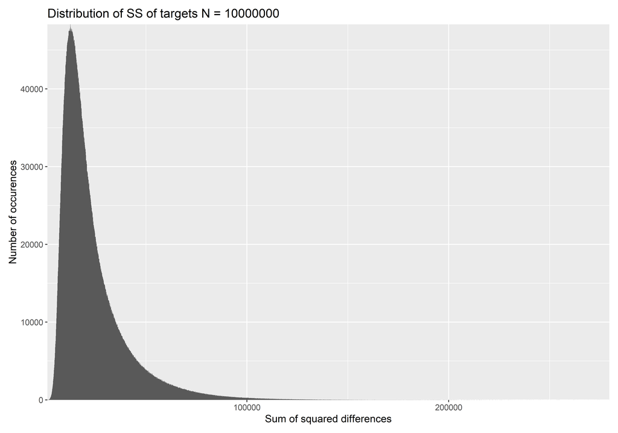

```r
# Displaying distribution
ggplot(data.frame(SS_target), aes(SS_target)) +
  geom_histogram(binwidth = 100) +
  theme(panel.margin = unit(2, "cm"),
        text = element_text(size = 12),
        plot.margin = margin(10, 10, 10, 10)) +
  labs(y = 'Number of occurences',
       x = 'Sum of squared differences',
       title = paste('Distribution of SS of targets N =', iterations)) +
  coord_cartesian(expand = FALSE)
```

Since the we do not need foils anymore, the only criterion for a good set is the spread of the kitchen objects (i.e. that this spread is equally spaced). The way I select the sets now is to sort them by their sum of squares (SS), print the twenty sets that have the lowest SS. After that, the best sets will be tested in the VR set-up to see whether they would work. I repeat this until I have five working sets.

# Sorting and printing

```r
# Sorting the sets
sortedtargets                   <- targets[,order(SS_target)]
objectOrientations              <- read.table("schemaVR3_stimulusSelection/data/objectsOrientations.txt", header = TRUE)
objectOrientations$locationNum  <- as.numeric(gsub("([spawnPoint])", "", objectOrientations$spawnPoint))
objectOrientations$fileName     <- as.character(objectOrientations$fileName)

# To give an idea what this files contains:
head(objectOrientations)
```

```
##   fileName  objectName  spawnPoint xRotation yRotation zRotation xPosition
## 1  1_1.png   microwave spawnPoint1         0        90         0 0.2439227
## 2  2_1.png kitchenRoll spawnPoint1         0        30         0 0.2439227
## 3  3_1.png    saucepan spawnPoint1         0        20         0 0.2439227
## 4  4_1.png     toaster spawnPoint1         0        60         0 0.1789228
## 5  5_1.png   fruitBowl spawnPoint1         0         0         0 0.2439227
## 6  6_1.png      teaPot spawnPoint1         0        30         0 0.2439227
##   yPosition zPosition locationNum
## 1  1.976172 -2.407146           1
## 2  1.906172 -2.407146           1
## 3  1.816172 -2.407146           1
## 4  1.806172 -2.519731           1
## 5  1.806172 -2.407146           1
## 6  1.906172 -2.407146           1
```

```r
nSets              <- 40
nObj               <- 20
objNames           <- c('microwave',
                      'kitchenRoll',
                      'saucepan',
                      'toaster',
                      'fruitBowl',
                      'teaPot',
                      'knife',
                      'mixer',
                      'bread',
                      'glassContainer',
                      'mug',
                      'dishes',
                      'towel',
                      'toy',
                      'bookPile',
                      'umbrella',
                      'hat',
                      'helmet',
                      'calendar',
                      'fan')

# Displaying results
objectLocation_sets <- data.frame(Set = rep(1:nSets, each = nObj),
                                  Objects = rep(objNames, nSets),
                                  Location = c(sortedtargets[, 1:nSets]))
kable(head(objectLocation_sets, n = nObj))
```

| Set | Objects | Location |
| --- | --- | --- |
| 1 | microwave | 13 |
| 1 | kitchenRoll | 9 |
| 1 | saucepan | 7 |
| 1 | toaster | 18 |
| 1 | fruitBowl | 16 |
| 1 | teaPot | 15 |
| 1 | knife | 6 |
| 1 | mixer | 11 |
| 1 | bread | 10 |
| 1 | glassContainer | 5 |
| 1 | mug | 3 |
| 1 | dishes | 8 |
| 1 | towel | 14 |
| 1 | toy | 1 |
| 1 | bookPile | 20 |
| 1 | umbrella | 2 |
| 1 | hat | 17 |
| 1 | helmet | 4 |
| 1 | calendar | 19 |
| 1 | fan | 12 |

```r
# Creating input files for VR part and rating part
fileName_VR     <- 'schemaVR3_stimulusSelection/schemaVR3_selections/schemaVR3_inputFile_VR_'
fileName_rating <- 'schemaVR3_stimulusSelection/schemaVR3_selections/schemaVR3_inputFile_rating_'
for(i in 1:nSets){
  tempSet <- subset(objectLocation_sets, objectLocation_sets$Set == i)
  # Choosing an appropriate NA value
  tempSet$fileName  <- NA_character_
  tempSet$xRotation <- NA_integer_
  tempSet$yRotation <- NA_integer_
  tempSet$zRotation <- NA_integer_
  tempSet$xPosition <- NA_real_
  tempSet$yPosition <- NA_real_
  tempSet$zPosition <- NA_real_

  for(j in 1:nObj){
    booleanIndex <- objectOrientations$objectName  == objNames[j] &
                    objectOrientations$locationNum == tempSet[tempSet$Objects == objNames[j], 'Location']
    tempSet$fileName[j]  <- objectOrientations[booleanIndex, 'fileName']
    tempSet$xRotation[j] <- objectOrientations[booleanIndex, 'xRotation']
    tempSet$yRotation[j] <- objectOrientations[booleanIndex, 'yRotation']
    tempSet$zRotation[j] <- objectOrientations[booleanIndex, 'zRotation']
    tempSet$xPosition[j] <- objectOrientations[booleanIndex, 'xPosition']
    tempSet$yPosition[j] <- objectOrientations[booleanIndex, 'yPosition']
    tempSet$zPosition[j] <- objectOrientations[booleanIndex, 'zPosition']

  }
  temp1 <- data.frame(var1 = tempSet$Objects,
                      var2 = tempSet$xRotation,
                      var3 = tempSet$yRotation,
                      var4 = tempSet$zRotation,
                      var5 = tempSet$xPosition,
                      var6 = tempSet$yPosition,
                      var7 = tempSet$zPosition)
  temp2 <- data.frame(var1 = tempSet$fileName,
                      var2 = 'How expected is/are that/these object(s) in that location?')
  write.table(temp1,
            paste(fileName_VR, i, '.txt', sep = ''),
            row.names = FALSE,
            quote = FALSE,
            sep = '\t',
            col.names = FALSE)
  write.table(temp2,
            paste(fileName_rating, i, '.txt', sep = ''),
            row.names = FALSE,
            quote = FALSE,
            sep = '\t',
            col.names = FALSE)
}
```

The last chunk creates input files on my disk.

# First selection

```r
selectedSets1 <- c(3, 4, 9, 13, 16)
```

The sets needed to be checked in the virtual environment - as described above. This important to make sure that all objects are easily visible and nothing else weird is going on. The knife for instance cannot be located at all locations because its flatness. I selected the following sets: 3, 4, 9, 13, 16. The question now is whether these sets are distinct enough from each other. I test this by examining how often objects are placed in the same location.

```r
selectedSets_frame <- data.frame(Objects = objNames,
                                 Set1 = sortedtargets[,selectedSets1[1]],
                                 Set2 = sortedtargets[,selectedSets1[2]],
                                 Set3 = sortedtargets[,selectedSets1[3]],
                                 Set4 = sortedtargets[,selectedSets1[4]],
                                 Set5 = sortedtargets[,selectedSets1[5]])

kable(selectedSets_frame)
```

| Objects | Set1 | Set2 | Set3 | Set4 | Set5 |
| --- | --- | --- | --- | --- | --- |
| microwave | 8 | 13 | 13 | 13 | 11 |
| kitchenRoll | 5 | 10 | 10 | 14 | 5 |
| saucepan | 19 | 15 | 5 | 16 | 10 |
| toaster | 4 | 9 | 20 | 18 | 19 |
| fruitBowl | 15 | 18 | 14 | 9 | 4 |
| teaPot | 12 | 2 | 6 | 11 | 15 |
| knife | 13 | 17 | 19 | 17 | 20 |
| mixer | 9 | 3 | 4 | 15 | 17 |
| bread | 16 | 4 | 15 | 4 | 16 |
| glassContainer | 7 | 14 | 8 | 6 | 6 |
| mug | 18 | 12 | 7 | 3 | 18 |
| dishes | 6 | 6 | 1 | 19 | 1 |
| towel | 11 | 1 | 18 | 5 | 12 |
| toy | 17 | 20 | 9 | 7 | 9 |
| bookPile | 14 | 16 | 11 | 10 | 14 |
| umbrella | 3 | 11 | 2 | 2 | 8 |
| hat | 10 | 5 | 12 | 8 | 3 |
| helmet | 1 | 7 | 16 | 20 | 2 |
| calendar | 2 | 8 | 17 | 1 | 7 |
| fan | 20 | 19 | 3 | 12 | 13 |

As one can see above, a lot of locations are repeated across the sets. For instance the microwave is at the same place in 3 out of 5 sets. Therefore I will check the remaining sets and extent the number of sets beyond twenty if necessary.

# Second selection

At first, I tried to increase the number of sets to 40 (as described above) and to select the sets myself trying to balance the number of repetitions, but this didn’t work out. Therefore, I used a brute-force sampling approach to find 5 sets, which work together. The 5 sets needed to fulfill 2 conditions. The first one is that there can’t be more than 2 locations that are the same for an object. Note that this means that there have to be at least 4 different locations per object. The second condition is that the knife must not be placed on one of the shelves because it can’t be seen there.

```r
# Preparation
set.seed(123)
runs        <- 10000
samplSize   <- 1000
setNotFound <- TRUE
index       <- 1

# Condition 1
# Not more than 2 locations can be the same for an object, which means that there have to be
# 4 different locations per objects
limit <- 2
# Condition 2
# The knife is never at a shelf location
shelfLocations <- c(1,5, 8, 9, 15)

while(setNotFound){
  selectedSets2 <- sample(1:samplSize, 5)
  selectedSets_frame <- data.frame(Objects = objNames,
                                 Set1 = sortedtargets[,selectedSets2[1]],
                                 Set2 = sortedtargets[,selectedSets2[2]],
                                 Set3 = sortedtargets[,selectedSets2[3]],
                                 Set4 = sortedtargets[,selectedSets2[4]],
                                 Set5 = sortedtargets[,selectedSets2[5]])

  setNotFound <- FALSE
  for(i in 1:20){
    if(max(table(as.numeric(selectedSets_frame[i, 2:6]))) > limit |
       sum(table(as.numeric(selectedSets_frame[i, 2:6])) == limit) > 1 |
       any(as.numeric(selectedSets_frame[7, 2:6]) %in% shelfLocations)){
      setNotFound <- TRUE
    }
  }
  if(index > runs){
    break
  }
  index <- index + 1
}
```

The five sets are selected by drawing a sample from the 1000 sets that have the lowest SS. Then, I check whether the selected sets fulfill the condition if they do, the loop is exited. If the procedure worked, setNotFound is FALSE.

```r
setNotFound
```

```
## [1] FALSE
```

The selected sets are 848, 498, 388, 246, 111 (see table below).

```r
kable(selectedSets_frame)
```

| Objects | Set1 | Set2 | Set3 | Set4 | Set5 |
| --- | --- | --- | --- | --- | --- |
| microwave | 19 | 10 | 11 | 13 | 13 |
| kitchenRoll | 2 | 19 | 4 | 15 | 11 |
| saucepan | 13 | 12 | 15 | 18 | 15 |
| toaster | 9 | 1 | 8 | 1 | 20 |
| fruitBowl | 1 | 16 | 18 | 16 | 6 |
| teaPot | 4 | 15 | 2 | 7 | 5 |
| knife | 14 | 13 | 6 | 14 | 10 |
| mixer | 17 | 14 | 14 | 3 | 12 |
| bread | 16 | 4 | 16 | 11 | 19 |
| glassContainer | 6 | 8 | 7 | 4 | 8 |
| mug | 11 | 3 | 20 | 19 | 3 |
| dishes | 10 | 20 | 10 | 12 | 9 |
| towel | 5 | 18 | 5 | 10 | 17 |
| toy | 15 | 9 | 1 | 6 | 2 |
| bookPile | 7 | 7 | 19 | 8 | 4 |
| umbrella | 8 | 5 | 12 | 17 | 18 |
| hat | 20 | 11 | 17 | 2 | 1 |
| helmet | 12 | 6 | 3 | 20 | 16 |
| calendar | 3 | 17 | 13 | 5 | 14 |
| fan | 18 | 2 | 9 | 9 | 7 |

To illustrate, where these sets are in the SS distribution, I mark them as vertical lines in the histogram below.

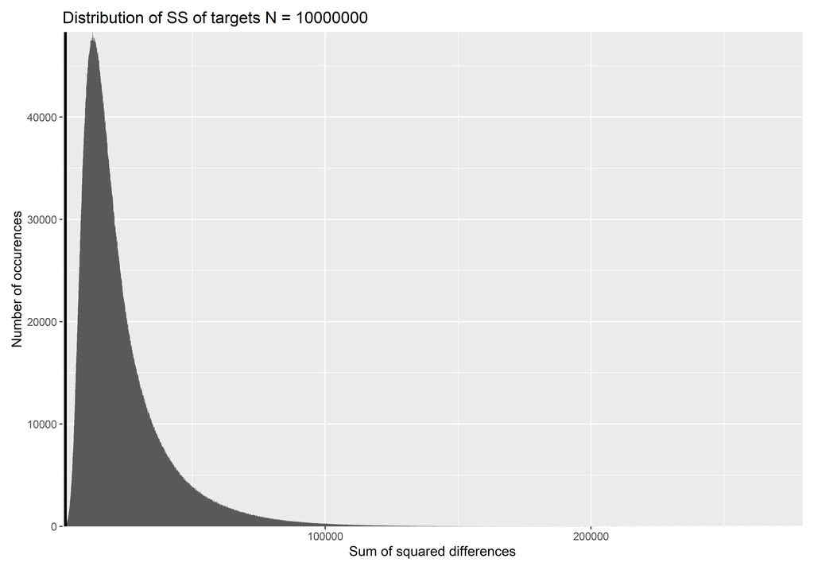

```r
# Getting SS values
selectedSets2_SS <- sort(SS_target)[selectedSets2]

# Displaying distribution
ggplot(data.frame(SS_target), aes(SS_target)) +
  geom_histogram(binwidth = 100) +
  geom_vline(xintercept = selectedSets2_SS) +
  theme(panel.margin = unit(2, "cm"),
        text = element_text(size = 12),
        plot.margin = margin(10, 10, 10, 10)) +
  labs(y = 'Number of occurences',
       x = 'Sum of squared differences',
       title = paste('Distribution of SS of targets N =', iterations)) +
  coord_cartesian(expand = FALSE)
```

To use these sets, they need to be saved in files.

```r
# Displaying results
objectLocation_sets <- data.frame(Set = rep(selectedSets2, each = nObj),
                                  Objects = rep(objNames, 5),
                                  Location = c(sortedtargets[, selectedSets2]))

for(i in 1:5){
  tempSet <- subset(objectLocation_sets, objectLocation_sets$Set == selectedSets2[i])
  # Choosing an appropriate NA value
  tempSet$fileName  <- NA_character_
  tempSet$xRotation <- NA_integer_
  tempSet$yRotation <- NA_integer_
  tempSet$zRotation <- NA_integer_
  tempSet$xPosition <- NA_real_
  tempSet$yPosition <- NA_real_
  tempSet$zPosition <- NA_real_

  for(j in 1:nObj){
    booleanIndex <- objectOrientations$objectName  == objNames[j] &
                    objectOrientations$locationNum == tempSet[tempSet$Objects == objNames[j], 'Location']
    tempSet$fileName[j]  <- objectOrientations[booleanIndex, 'fileName']
    tempSet$xRotation[j] <- objectOrientations[booleanIndex, 'xRotation']
    tempSet$yRotation[j] <- objectOrientations[booleanIndex, 'yRotation']
    tempSet$zRotation[j] <- objectOrientations[booleanIndex, 'zRotation']
    tempSet$xPosition[j] <- objectOrientations[booleanIndex, 'xPosition']
    tempSet$yPosition[j] <- objectOrientations[booleanIndex, 'yPosition']
    tempSet$zPosition[j] <- objectOrientations[booleanIndex, 'zPosition']

  }
  temp1 <- data.frame(var1 = tempSet$Objects,
                      var2 = tempSet$xRotation,
                      var3 = tempSet$yRotation,
                      var4 = tempSet$zRotation,
                      var5 = tempSet$xPosition,
                      var6 = tempSet$yPosition,
                      var7 = tempSet$zPosition)
  temp2 <- data.frame(var1 = tempSet$fileName,
                      var2 = 'How expected is/are that/these object(s) in that location?')
  write.table(temp1,
            paste(fileName_VR, selectedSets2[i], '.txt', sep = ''),
            row.names = FALSE,
            quote = FALSE,
            sep = '\t',
            col.names = FALSE)
  write.table(temp2,
            paste(fileName_rating, selectedSets2[i], '.txt', sep = ''),
            row.names = FALSE,
            quote = FALSE,
            sep = '\t',
            col.names = FALSE)
}
```

As the last step, I was checking whether these sets work in VR again, which they did.